# Daily Activity Pattern Analysis

A pipeline to analyze and visualize species daily activity patterns

Nicolás Caruso

May 2023

# Introduction

Welcome to the Daily Activity Pattern Analysis Notebook! In this notebook, we will explore the fascinating world of animal behavior by analyzing the daily activity patterns of multiple species and examining the level of overlap among them. Understanding these patterns provides valuable insights into ecological roles, resource utilization, and species interactions within ecosystems. Through statistical analyses and data visualization, we aim to identify peak activity times, assess temporal overlap, and help to understand the factors influencing variations in activity patterns.

By studying the daily activity patterns of different species, we gain a deeper understanding of their adaptations, survival strategies, and the broader functioning of ecosystems. Animals exhibit a diverse range of activity patterns influenced by evolutionary history, environmental conditions, and interactions with other organisms. Understanding them we can unlock essential insights into species interactions and their impact on community structure and ecosystem dynamics.

Throughout this notebook, we provide step-by-step instructions, code snippets, and data visualizations to facilitate your analysis. By actively engaging with the data and interpreting the results, you can uncover the intricate relationships embedded within daily activity patterns. The analysis of these patterns serves as a powerful tool for understanding animal behavior and gaining a deeper appreciation for the complexities of our natural world.

# Code

### Packages needed

R is a programming language specifically designed for statistical analysis. Like many other programming languages, it provides libraries (also known as packages) that enable various types of analyses. It is customary to list all the required packages at the beginning of the analysis. To use a package, you need to install it first using the `install.packages()` command, and then load it using the `library()` function.

```r
library(circular)
library(overlap)
library(png)
library(ggplot2)
library(dplyr)
library(grid) #rasterGrob
library(cowplot) #ggdraw
```

### getting data

The `setwd()` command sets the working directory, which allows you to directly read all the files in that directory without having to type the entire path again. Then, with the read.csv() command, we load the file containing the data. In essence, each row in the file represents a photograph, while the columns contain information about the species and the corresponding datetime of the picture.

```r
# set the working directory (unmute the line before run)
#setwd("pathToYourWorkingDirectory")

# load data
total<-read.csv("registros2.csv")
```

### Processing the data

Following the recommendation of the package authors and in order to represent time as a circular variable, we will convert the datetime values into radians (an into decimal first) for further analysis.

```r
# This function splits the time column into hours, minutes, and seconds, and then applies the formula to convert it into decimal hours.

total$decimal <- sapply(strsplit(total$Time,":"), function(x){
  x <- as.numeric(x)
  x[1]+x[2]/60+ x[3]/3600
}
)

# Convert into radians
#total$timeRad<-total$decimal*2*pi

total$timeRad<-total$decimal/24*2*pi
```

### Rayleigh test

The Rayleigh test is a statistical test used to determine if there is a significant circular (periodic) pattern in a set of angular data. It assesses whether the observed angles are uniformly distributed or exhibit a preferred direction. In the context of analyzing daily activity patterns, the Rayleigh test can be applied to examine if there is a significant preference for specific times of the day in the behavior of the studied species. If the test indicates a significant result, it suggests the presence of a non-random pattern in the activity behavior, indicating a preferred time or direction of activity.

```r
# select the species
sp <- total %>%
  filter(Species== "Imaginosa nicolensis")

#test Rayleigh
rayleigh.test(sp$timeRad)
```

```
##
##        Rayleigh Test of Uniformity
##        General Unimodal Alternative
##
## Test Statistic:  0.6904
## P-value:  0
```

### Plotting daily activity patterns using Kernel

Kernel density estimation is a powerful technique that can be used to analyze daily activity patterns in a comprehensive and informative manner. By applying kernel density estimation to temporal data, such as the timing of animal behaviors throughout the day, we can obtain a smooth and continuous representation of the activity distribution. This estimation method allows us to identify the peaks and troughs of activity, revealing the preferred time periods and intensity of certain behaviors. By visualizing the kernel density estimate, we can gain insights into the temporal patterns, detect bimodal or multimodal activity distributions, and observe potential variations across different species. Additionally, kernel density estimation enables the quantification of overlap between activity patterns, allowing for a deeper understanding of potential interactions and resource utilization among species.

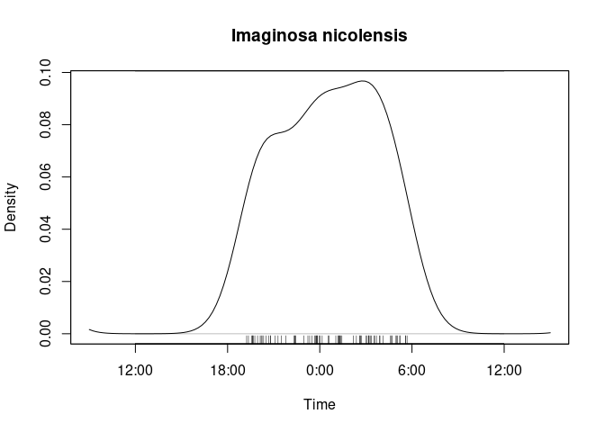

```r
#plot
sp_name='Imaginosa nicolensis'

densityPlot(sp$timeRad,rug=T, main=sp_name, adjust=2, xlab="Time",
            ylab="Density", xcenter = 'midnight',extend = F)
```

### A much nicer plot

In order to explore and visualize the daily activity patterns we can also utilize a polar plot, which is a specialized variation of a histogram specifically designed for directional data. While traditional histograms are suitable for representing frequencies in numerical data, a polar plot is particularly well-suited for analyzing circular or angular data, such as time or direction. By applying a polar plot to our analysis of daily activity patterns, we can effectively depict the distribution and concentration of activity across the 24-hour day. The circular nature of the plot allows us to visualize the cyclic nature of behavior, identifying peaks and troughs that correspond to different times of the day. This representation provides a clear and intuitive understanding of the dominant activity periods and the intensity of activity during specific time intervals.

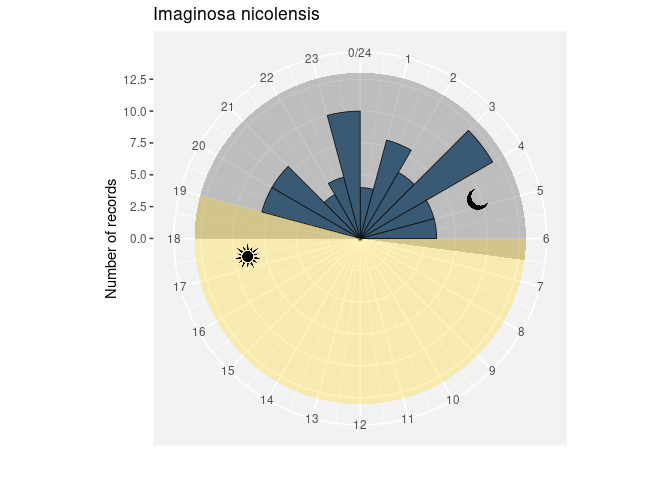

```r
# plot
plot<-ggplot(sp, aes(x = decimal))+
      geom_histogram(breaks = seq(0, 24),
                     fill="steelblue4",
                     colour = "black", linewidth=0.3)+
      scale_x_continuous("", limits = c(0, 24),
                         breaks = seq(0, 24),
                         labels = seq(0, 24))+

      # here you define the night hours
      annotate("rect",
               xmin = c(18,0), xmax = c(24, 6.5),
               ymin = 0, ymax = 13,
               alpha=0.3,
               fill="grey25")+

      # here you define the day haurs
      annotate("rect",
               xmin=6, xmax = 19,
               ymin = 0, ymax = 13,
               alpha=0.3, fill="#FFD819")+

      # title and axes labels
      labs(title="Imaginosa nicolensis",
            y= "Number of records")+

      # convert to circular plot
      coord_polar(start = 0)  +

      # background color
      theme(panel.background = element_rect(fill = 'grey95'))


# sun and moon images
sun <- readPNG("sun.png")
moon <- readPNG("moon.png")
sun<- rasterGrob(sun, interpolate = T)
moon<- rasterGrob(moon, interpolate = T)

# add the images
plot<-ggdraw(plot)+
      draw_grob(sun,0.33, 0.43, 0.08, 0.07)+
      draw_grob(moon,0.67, 0.55, 0.08, 0.07, scale = 0.75)

# print plot
print(plot)
```

### Temporal overlap between two species

We will now calculate density curves for two species and plot them overlaid. Additionally, the “Overlap” package allows us to calculate an overlap index and its confidence interval.

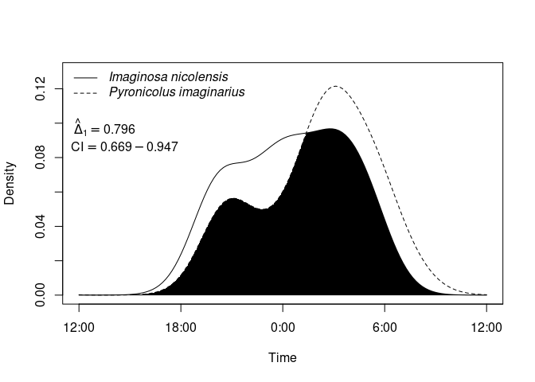

```r
sp1 <- total %>%
  filter(Species== "Imaginosa nicolensis")

sp2 <- total %>%
  filter(Species== "Pyronicolus imaginarius")

# overlap indexes (which one to use depends on the sampling size. See Ridout & Linkie 2009)
over<-overlapEst(sp1$timeRad, sp2$timeRad)

# Bootstrap confidence intervals
sp1.boot<-resample(sp1$timeRad,1000)
sp2.boot<-resample(sp2$timeRad,1000)
over_CI<-bootEst(sp1.boot,sp2.boot,adjust=c(1,NA,NA))
CI<-bootCI(over[1],over_CI[,1])

# plot
overlapPlot(sp1$timeRad,
            sp2$timeRad,
            main=expression(""),
            xlab="Time",
            ylab="Density",
            ylim=c(0,0.13),
            linecol=c("black","black"),
            olapcol="black",
            frame.plot=T,
            adjust = 2,
            xcenter = 'midnight')

#legend
legend("topleft",
       c(expression(italic("Imaginosa nicolensis")),
         expression(italic("Pyronicolus imaginarius"))),
       lty=c(1,2),
       col=c(1,1),
       bty="n")

#delta
mtext(bquote(hat(Delta)[1] == .(round(over[1],3))),
      side = 3,
      line = -5,
      at = -10.5)

#confidence interval
mtext(bquote('CI' == .(round(CI[1,1],3)) - .(round(CI[1,2],3))),
      side = 3,
      line=-6,
      at=-9.3)
```